# Bellabeat

Pilar Wilches

2023-10-03

## Analysis Process for the case study: Bellabeat

### Goal: Analyse data from smart devices to understand consumer use of smart device

First of all we install packages and libraries for data clean and visualization

```r
options(repos = "https://cran.rstudio.com/")

install.packages("here")
install.packages("skimr")
install.packages("janitor")
```

```r
install.packages("ggplot2")
library("here")
library("skimr")
library("janitor")
library("dplyr")
library("lubridate")
library("readr")
library("ggplot2")
```

# Work with file dailyIntensities_merged.csv

## 1. Import Data and previsualization

Now, I import the file: dailyIntensities_merged.csv and create the data frame, With this data frame I want know the relationship between the days of the week and the person activity.

```r
setwd("/Users/maria/Bellabeat")
dailyIntensities_df <- read_csv("dailyIntensities_merged.csv")
```

Then, I preview the data with different functions for review cols, rows, type of data.

```r
View(dailyIntensities_df)

glimpse(dailyIntensities_df)
```

```
## Rows: 940
## Columns: 10
## $ Id                       <dbl> 1503960366, 1503960366, 1503960366, 150396036…
## $ ActivityDay              <chr> "4/12/2016", "4/13/2016", "4/14/2016", "4/15/…
## $ SedentaryMinutes         <dbl> 728, 776, 1218, 726, 773, 539, 1149, 775, 818…
## $ LightlyActiveMinutes     <dbl> 328, 217, 181, 209, 221, 164, 233, 264, 205, …
## $ FairlyActiveMinutes      <dbl> 13, 19, 11, 34, 10, 20, 16, 31, 12, 8, 27, 21…
## $ VeryActiveMinutes        <dbl> 25, 21, 30, 29, 36, 38, 42, 50, 28, 19, 66, 4…
## $ SedentaryActiveDistance  <dbl> 0, 0, 0, 0, 0, 0, 0, 0, 0, 0, 0, 0, 0, 0, 0, …
## $ LightActiveDistance      <dbl> 6.06, 4.71, 3.91, 2.83, 5.04, 2.51, 4.71, 5.0…
## $ ModeratelyActiveDistance <dbl> 0.55, 0.69, 0.40, 1.26, 0.41, 0.78, 0.64, 1.3…
## $ VeryActiveDistance       <dbl> 1.88, 1.57, 2.44, 2.14, 2.71, 3.19, 3.25, 3.5…
```

```r
colnames(dailyIntensities_df)
```

```
##  [1] "Id"                       "ActivityDay"
##  [3] "SedentaryMinutes"         "LightlyActiveMinutes"
##  [5] "FairlyActiveMinutes"      "VeryActiveMinutes"
##  [7] "SedentaryActiveDistance"  "LightActiveDistance"
##  [9] "ModeratelyActiveDistance" "VeryActiveDistance"
```

## 2. Data cleaning

I check the consistence of data frame

```r
clean_names(dailyIntensities_df)
```

```
## # A tibble: 940 × 10
##            id activity_day sedentary_minutes lightly_active_minutes
##         <dbl> <chr>                    <dbl>                  <dbl>
##  1 1503960366 4/12/2016                  728                    328
##  2 1503960366 4/13/2016                  776                    217
##  3 1503960366 4/14/2016                 1218                    181
##  4 1503960366 4/15/2016                  726                    209
##  5 1503960366 4/16/2016                  773                    221
##  6 1503960366 4/17/2016                  539                    164
##  7 1503960366 4/18/2016                 1149                    233
##  8 1503960366 4/19/2016                  775                    264
##  9 1503960366 4/20/2016                  818                    205
## 10 1503960366 4/21/2016                  838                    211
## # ℹ 930 more rows
## # ℹ 6 more variables: fairly_active_minutes <dbl>, very_active_minutes <dbl>,
## #   sedentary_active_distance <dbl>, light_active_distance <dbl>,
## #   moderately_active_distance <dbl>, very_active_distance <dbl>
```

When I apply this function, I see that the name of the columns can be improved according to the syntax of clean code, so I change the column names type snake case

```r
 rename_columns_to_snake_case <- function(dataframe){
  dataframe %>%
    rename_with(~tolower(gsub("([a-z0-9])([A-Z])", "\\1_\\2", .)),.cols = everything())
 }

dailyIntensities_new_df <- rename_columns_to_snake_case(dailyIntensities_df)

View(dailyIntensities_new_df)
```

## 3. Manipulation/Processing of data

```r
dailyIntensities_new_df <- dailyIntensities_new_df %>%
  mutate(day_of_week = weekdays(as.Date(activity_day, format="%m/%d/%Y")) )
```

Now, it is very important to have statistics, below is the comparison:

Day of week vrs. Average active minutes

```r
mean_active_minutes_df <- dailyIntensities_new_df %>%
  group_by(day_of_week) %>%
  summarize(mean_active_minutes =      round(mean(very_active_minutes+fairly_active_minutes+lightly_active_minutes))) %>%
  arrange(mean_active_minutes)
```

Day of week vrs. Sedentary minutes

```r
dailyIntensities_new_df %>%
  group_by(day_of_week) %>%
  summarize(mean_sedentary_minutes =round(mean(sedentary_minutes))) %>%
  arrange(desc(mean_sedentary_minutes))
```

```
## # A tibble: 7 × 2
##   day_of_week mean_sedentary_minutes
##   <chr>                        <dbl>
## 1 Monday                        1028
## 2 Tuesday                       1007
## 3 Friday                        1000
## 4 Sunday                         990
## 5 Wednesday                      989
## 6 Saturday                       964
## 7 Thursday                       962
```

# Work with file dailyActivity_merged.csv

## 1. Import Data and previsualization

Now, I import the file: dailyActivity_merged.csv and create the data frame, With this data frame I want know the relationship between the days of the week and the calories, steps and activity in general.

```r
setwd("/Users/maria/Bellabeat")
dailyActivity_df <- read_csv("dailyActivity_merged.csv")
```

Then, I preview the data with different functions for review cols, rows, type of data.

```r
View(dailyActivity_df)

glimpse(dailyActivity_df)
```

```
## Rows: 940
## Columns: 15
## $ Id                       <dbl> 1503960366, 1503960366, 1503960366, 150396036…
## $ ActivityDate             <chr> "4/12/2016", "4/13/2016", "4/14/2016", "4/15/…
## $ TotalSteps               <dbl> 13162, 10735, 10460, 9762, 12669, 9705, 13019…
## $ TotalDistance            <dbl> 8.50, 6.97, 6.74, 6.28, 8.16, 6.48, 8.59, 9.8…
## $ TrackerDistance          <dbl> 8.50, 6.97, 6.74, 6.28, 8.16, 6.48, 8.59, 9.8…
## $ LoggedActivitiesDistance <dbl> 0, 0, 0, 0, 0, 0, 0, 0, 0, 0, 0, 0, 0, 0, 0, …
## $ VeryActiveDistance       <dbl> 1.88, 1.57, 2.44, 2.14, 2.71, 3.19, 3.25, 3.5…
## $ ModeratelyActiveDistance <dbl> 0.55, 0.69, 0.40, 1.26, 0.41, 0.78, 0.64, 1.3…
## $ LightActiveDistance      <dbl> 6.06, 4.71, 3.91, 2.83, 5.04, 2.51, 4.71, 5.0…
## $ SedentaryActiveDistance  <dbl> 0, 0, 0, 0, 0, 0, 0, 0, 0, 0, 0, 0, 0, 0, 0, …
## $ VeryActiveMinutes        <dbl> 25, 21, 30, 29, 36, 38, 42, 50, 28, 19, 66, 4…
## $ FairlyActiveMinutes      <dbl> 13, 19, 11, 34, 10, 20, 16, 31, 12, 8, 27, 21…
## $ LightlyActiveMinutes     <dbl> 328, 217, 181, 209, 221, 164, 233, 264, 205, …
## $ SedentaryMinutes         <dbl> 728, 776, 1218, 726, 773, 539, 1149, 775, 818…
## $ Calories                 <dbl> 1985, 1797, 1776, 1745, 1863, 1728, 1921, 203…
```

This visualization is very important, for instance, the column ActivityDay is character and must be date type for the analysis.

```r
colnames(dailyActivity_df)
```

```
##  [1] "Id"                       "ActivityDate"
##  [3] "TotalSteps"               "TotalDistance"
##  [5] "TrackerDistance"          "LoggedActivitiesDistance"
##  [7] "VeryActiveDistance"       "ModeratelyActiveDistance"
##  [9] "LightActiveDistance"      "SedentaryActiveDistance"
## [11] "VeryActiveMinutes"        "FairlyActiveMinutes"
## [13] "LightlyActiveMinutes"     "SedentaryMinutes"
## [15] "Calories"
```

## 2. Data cleaning

I check the consistence of data frame

```r
clean_names(dailyActivity_df)
```

```
## # A tibble: 940 × 15
##            id activity_date total_steps total_distance tracker_distance
##         <dbl> <chr>               <dbl>          <dbl>            <dbl>
##  1 1503960366 4/12/2016           13162           8.5              8.5
##  2 1503960366 4/13/2016           10735           6.97             6.97
##  3 1503960366 4/14/2016           10460           6.74             6.74
##  4 1503960366 4/15/2016            9762           6.28             6.28
##  5 1503960366 4/16/2016           12669           8.16             8.16
##  6 1503960366 4/17/2016            9705           6.48             6.48
##  7 1503960366 4/18/2016           13019           8.59             8.59
##  8 1503960366 4/19/2016           15506           9.88             9.88
##  9 1503960366 4/20/2016           10544           6.68             6.68
## 10 1503960366 4/21/2016            9819           6.34             6.34
## # ℹ 930 more rows
## # ℹ 10 more variables: logged_activities_distance <dbl>,
## #   very_active_distance <dbl>, moderately_active_distance <dbl>,
## #   light_active_distance <dbl>, sedentary_active_distance <dbl>,
## #   very_active_minutes <dbl>, fairly_active_minutes <dbl>,
## #   lightly_active_minutes <dbl>, sedentary_minutes <dbl>, calories <dbl>
```

When I apply this function, I see that the name of the columns can be improved according the syntax of clean code, so I apply the function created previously, which changes the column names like snake case

```r
dailyActivity_new_df <- rename_columns_to_snake_case(dailyActivity_df)

View(dailyActivity_new_df)
```

## 3. Manipulation/Processing of data

And this point, I used the same code for change and add the column name day_of_week

```r
dailyActivity_new_df <- dailyActivity_new_df %>%
  mutate(day_of_week = weekdays(as.Date(activity_date, format="%m/%d/%Y")) )
```

Check the new column:

```r
 View(dailyActivity_new_df)
```

Now, it’s statistics’ time:

Day of week vrs. Calories

```r
 dailyActivity_new_df %>%
  group_by(day_of_week) %>%
  summarize(mean_calories = round(mean(calories,na.rm = TRUE)),
            mean_steps = round(mean(total_steps,na.rm = TRUE))) %>%
  arrange(desc(mean_calories))
```

```
## # A tibble: 7 × 3
##   day_of_week mean_calories mean_steps
##   <chr>               <dbl>      <dbl>
## 1 Tuesday              2356       8125
## 2 Saturday             2355       8153
## 3 Friday               2332       7448
## 4 Monday               2324       7781
## 5 Wednesday            2303       7559
## 6 Sunday               2263       6933
## 7 Thursday             2200       7406
```

```r
 mean_calories_df <- dailyActivity_new_df %>%
  group_by(day_of_week) %>%
  summarize(mean_calories = round(mean(calories, na.rm = TRUE))) %>%
  arrange(desc(mean_calories))

  mean_total_steps_df <- dailyActivity_new_df %>%
  group_by(day_of_week) %>%
  summarize(mean_steps = round(mean(total_steps, na.rm = TRUE))) %>%
  arrange(desc(mean_steps))
```

# Visualization of data

In this step, I’ll show the different graphics of my data:

ggplot

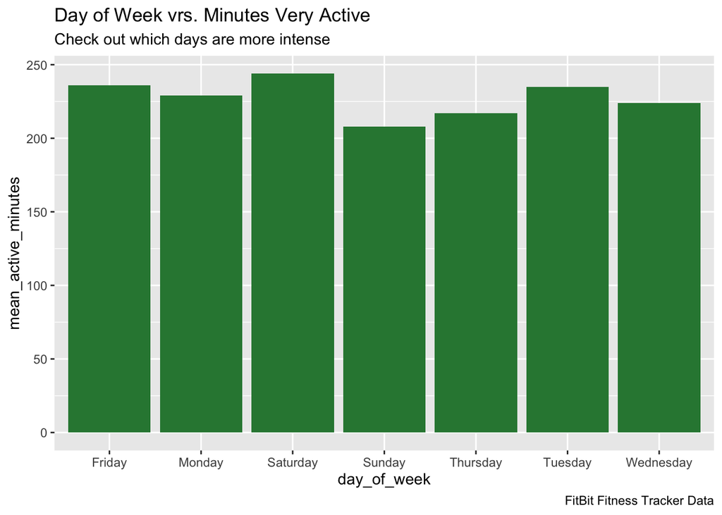

```r
ggplot(data = mean_active_minutes_df) +
  geom_col(mapping = aes(x= day_of_week, y=mean_active_minutes), fill="#2e8540")+
  labs(title = "Day of Week vrs. Minutes Very Active",
       subtitle = "Check out which days are more intense",
       caption = "FitBit Fitness Tracker Data")
```

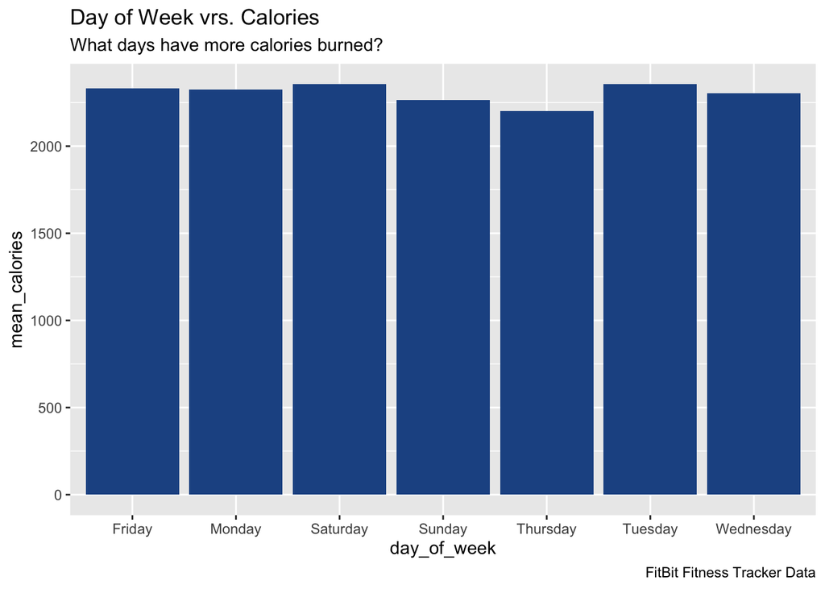

```r
ggplot(data = mean_calories_df) +
  geom_col(mapping = aes(x= day_of_week, y=mean_calories), fill="#205493")+
  labs(title = "Day of Week vrs. Calories",
       subtitle = "What days have more calories burned?",
       caption = "FitBit Fitness Tracker Data")
```

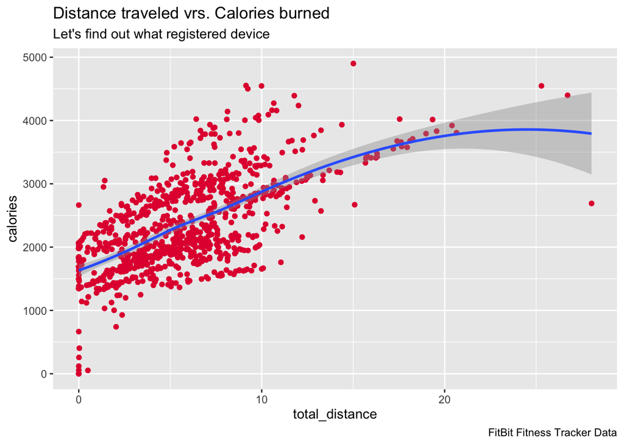

```r
ggplot(data = dailyActivity_new_df) +
  geom_point(mapping = aes(x= total_distance, y=calories), color="#e31c3d") +
  geom_smooth(mapping = aes(x= total_distance, y=calories)) +
  labs(title = "Distance traveled vrs. Calories burned",
       subtitle = "Let's find out what registered device",
       caption = "FitBit Fitness Tracker Data")
```

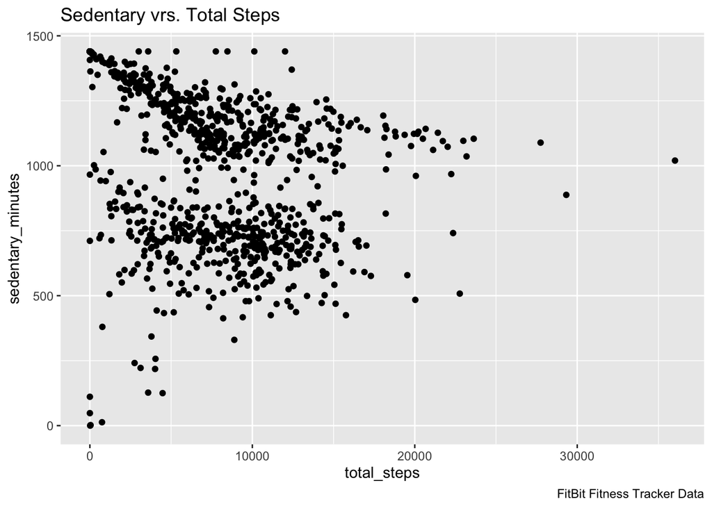

```r
ggplot(data=dailyActivity_new_df, aes(x=total_steps, y=sedentary_minutes)) +
  geom_point() +
  labs(title = "Sedentary vrs. Total Steps ",
       caption = "FitBit Fitness Tracker Data")
```

# Technical Notes

- I could have named all variables with clean code I was able to used a function to change the data to the day of week and not repeat code.
- As I progressed in the project, I became more familiar with the files, so I realized note that I could have started with the activity file and not Intensitive file csv.
- In data cleaning I didn’t delete the day with zero activity because I don’t know if it is a mistake, this situation in a real case, I would ask the organization.